# Moderation Analysis

ChatGPT 4o

2025-01-21

## 1 起源

调节分析（Moderation Analysis）是一种用于探讨自变量和因变量之间关系的统计方法，特别是考察这种关系是否会受到第三个变量（调节变量）的影响。调节分析最早由心理学家在20世纪中期提出，旨在揭示某些因素如何改变两个变量之间的关联强度和方向。它在心理学、社会科学和管理学等领域广泛应用，有助于揭示复杂的因果关系和不同情境下的效应差异。

## 2 原理

调节分析的核心思想是通过引入调节变量（Moderator），探讨自变量（X）与因变量（Y）之间的关系是否受到该调节变量（Z）的影响。调节变量可以增强、减弱或改变自变量对因变量的影响。调节分析通常包括以下几个主要部分：

1. **主效应（Main Effect）**：自变量（X）对因变量（Y）的直接影响。
2. **调节效应（Interaction Effect）**：调节变量（Z）与自变量（X）之间的交互作用项的影响。
3. **总效应（Total Effect）**：自变量、调节变量及其交互项对因变量的总体影响。

数学模型可描述为：

$$Y = \beta_0 + \beta_1 X + \beta_2 Z + \beta_3 (X \times Z) + \epsilon$$

其中，$\beta_3$ 是调节效应系数，表示自变量和调节变量的交互作用对因变量的影响。如果 $\beta_3$ 显著，则说明调节效应存在。

## 3 适用范围

调节分析适用于以下情况：

- **探讨情境或条件效应**：当研究者希望探讨某种关系在不同情境或条件下的变化时，调节分析非常合适。
- **分类或连续调节变量**：调节变量可以是分类变量（如性别、群体）或连续变量（如年龄、收入）。
- **数据符合回归分析假设**：调节分析基于回归模型，数据应满足线性关系、正态性等基本假设。

## 4 应用情境

调节分析在许多领域中有广泛应用，例如：

- **心理学研究**：探讨压力对工作绩效的影响是否因社会支持的不同而不同。
- **教育研究**：分析学生的学习成绩是否因教学风格不同而受家庭环境的调节。
- **管理学研究**：研究领导风格对员工绩效的影响是否受到组织文化的调节。
- **医学研究**：探讨某种治疗效果是否因患者的生活习惯（如锻炼频率）而有所不同。

## 5 优缺点

### 优点

- **揭示条件效应**：调节分析能够揭示自变量对因变量的影响是否会因某些因素而改变，有助于更全面地理解变量之间的关系。
- **识别边界条件**：可以帮助研究者识别自变量和因变量之间关系的边界条件，即在什么情况下这种关系存在或不存在。
- **灵活性强**：调节变量可以是分类或连续的，因此适用性非常广泛。

### 缺点

- **解释难度较高**：交互效应的解释往往比较复杂，尤其是调节变量是连续型时，解释其效应需要结合具体数值。
- **对数据的要求较高**：调节分析基于回归模型，对数据的线性关系、正态性和独立性有较高要求。
- **多重共线性问题**：当自变量、调节变量及其交互项存在较强的相关性时，可能导致结果不稳定。

## 6 在R中的实现及结果解释

在R中，调节分析可以通过`lm()`函数实现，并使用交互项来考察调节效应。以下是一个实现示例：

```r
# 加载必要的包
library(ggplot2)

# 示例数据：自变量X、调节变量Z和因变量Y
set.seed(123)
X <- rnorm(100, mean = 5, sd = 2)
Z <- rnorm(100, mean = 3, sd = 1)
Y <- 0.5 * X + 0.3 * Z + 0.4 * X * Z + rnorm(100)

# 创建数据框
data <- data.frame(X = X, Z = Z, Y = Y)

# 进行调节分析
model <- lm(Y ~ X * Z, data = data)

# 输出结果
summary(model)
```

```
##
## Call:
## lm(formula = Y ~ X * Z, data = data)
##
## Residuals:
##     Min      1Q  Median      3Q     Max
## -1.8719 -0.6777 -0.1086  0.5897  2.3166
##
## Coefficients:
##             Estimate Std. Error t value Pr(>|t|)
## (Intercept)  1.46328    0.87185   1.678   0.0965 .
## X            0.21494    0.16565   1.298   0.1976
## Z           -0.06342    0.29556  -0.215   0.8305
## X:Z          0.47955    0.05725   8.377  4.5e-13 ***
## ---
## Signif. codes:  0 '***' 0.001 '**' 0.01 '*' 0.05 '.' 0.1 ' ' 1
##
## Residual standard error: 0.9468 on 96 degrees of freedom
## Multiple R-squared:  0.9358, Adjusted R-squared:  0.9338
## F-statistic: 466.5 on 3 and 96 DF,  p-value: < 2.2e-16
```

```r
str(model)
```

[output not shown]

### 结果解释

- **自变量和调节变量的主效应**：回归输出中，$\beta_1$ 和 $\beta_2$ 分别表示自变量和调节变量对因变量的直接影响。如果其p值小于显著性水平（如0.05），则认为该主效应显著。
- **交互效应（X:Z）**：$\beta_3$ 为交互项的回归系数，表示调节效应的大小。如果交互项的p值显著，说明调节变量对自变量与因变量之间的关系有显著调节作用。

例如，如果输出结果显示交互项的p值小于0.05，则可以认为调节效应显著，即自变量对因变量的影响受到调节变量的调节。

### 包含与不包含交互项的模型比较

为了更好地理解调节效应，可以将包含交互项的模型与不包含交互项的模型进行比较，以评估交互项对模型拟合效果的贡献。

以下是在R中进行包含与不包含交互项模型比较的示例：

```r
# 进行不包含交互项的回归分析
model_no_interaction <- lm(Y ~ X + Z, data = data)
summary(model_no_interaction)
```

```
##
## Call:
## lm(formula = Y ~ X + Z, data = data)
##
## Residuals:
##     Min      1Q  Median      3Q     Max
## -3.1859 -0.6760 -0.0591  0.7379  3.5654
##
## Coefficients:
##             Estimate Std. Error t value Pr(>|t|)
## (Intercept)  -4.9669     0.5411   -9.18 7.93e-15 ***
## X             1.5319     0.0683   22.43  < 2e-16 ***
## Z             2.2708     0.1290   17.61  < 2e-16 ***
## ---
## Signif. codes:  0 '***' 0.001 '**' 0.01 '*' 0.05 '.' 0.1 ' ' 1
##
## Residual standard error: 1.239 on 97 degrees of freedom
## Multiple R-squared:  0.8889, Adjusted R-squared:  0.8866
## F-statistic:   388 on 2 and 97 DF,  p-value: < 2.2e-16
```

```r
# 进行包含交互项的回归分析
model_interaction <- lm(Y ~ X * Z, data = data)
summary(model_interaction)
```

```
##
## Call:
## lm(formula = Y ~ X * Z, data = data)
##
## Residuals:
##     Min      1Q  Median      3Q     Max
## -1.8719 -0.6777 -0.1086  0.5897  2.3166
##
## Coefficients:
##             Estimate Std. Error t value Pr(>|t|)
## (Intercept)  1.46328    0.87185   1.678   0.0965 .
## X            0.21494    0.16565   1.298   0.1976
## Z           -0.06342    0.29556  -0.215   0.8305
## X:Z          0.47955    0.05725   8.377  4.5e-13 ***
## ---
## Signif. codes:  0 '***' 0.001 '**' 0.01 '*' 0.05 '.' 0.1 ' ' 1
##
## Residual standard error: 0.9468 on 96 degrees of freedom
## Multiple R-squared:  0.9358, Adjusted R-squared:  0.9338
## F-statistic: 466.5 on 3 and 96 DF,  p-value: < 2.2e-16
```

```r
# 比较两个模型
anova(model_no_interaction, model_interaction)
```

```
## Analysis of Variance Table
##
## Model 1: Y ~ X + Z
## Model 2: Y ~ X * Z
##   Res.Df     RSS Df Sum of Sq      F    Pr(>F)
## 1     97 148.952
## 2     96  86.051  1    62.902 70.174 4.497e-13 ***
## ---
## Signif. codes:  0 '***' 0.001 '**' 0.01 '*' 0.05 '.' 0.1 ' ' 1
```

```r
str(model_no_interaction)
```

[output not shown]

```r
str(model_interaction)
```

[output not shown]

### 结果解释

- **不包含交互项的模型**：`model_no_interaction` 仅包含自变量和调节变量的主效应。该模型用于检验自变量和调节变量各自对因变量的影响。
- **包含交互项的模型**：`model_interaction` 包含自变量、调节变量及其交互项，用于检验调节效应。
- **模型比较**：通过`anova()`函数比较两个模型，查看交互项是否显著改善了模型的拟合效果。如果`anova()`输出的p值显著（小于0.05），则说明包含交互项的模型显著优于不包含交互项的模型，即调节效应显著。

这种比较可以帮助我们更好地理解调节变量是否在自变量与因变量的关系中起到了显著作用。

### 结果的可视化

可以使用`ggplot2`包对调节分析的结果进行可视化，以直观地展示调节效应。

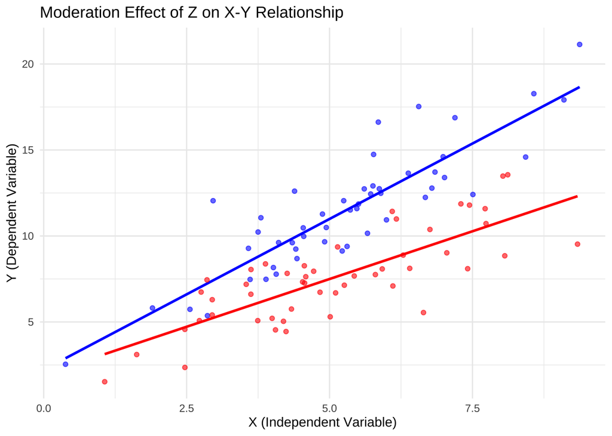

```r
# 可视化调节效应
# 按照调节变量Z的高低分组绘制自变量X与因变量Y的关系
high_Z <- data[data$Z > median(data$Z), ]
low_Z <- data[data$Z <= median(data$Z), ]

# 绘制散点图和拟合线
ggplot() +
  geom_point(data = high_Z, aes(x = X, y = Y), color = "blue", alpha = 0.6) +
  geom_smooth(data = high_Z, aes(x = X, y = Y), method = "lm", color = "blue", se = FALSE) +
  geom_point(data = low_Z, aes(x = X, y = Y), color = "red", alpha = 0.6) +
  geom_smooth(data = low_Z, aes(x = X, y = Y), method = "lm", color = "red", se = FALSE) +
  labs(title = "Moderation Effect of Z on X-Y Relationship", x = "X (Independent Variable)", y = "Y (Dependent Variable)") +
  theme_minimal()
```

上述代码将绘制两组散点图，分别表示调节变量Z较高和较低时，自变量X与因变量Y之间的关系。通过不同颜色的拟合线，可以直观地观察调节效应，即调节变量对自变量和因变量关系的影响。

## 7 小结

- 调节分析是一种用于探讨自变量和因变量之间关系是否受到调节变量影响的统计方法。
- 适用于探讨条件或情境效应，帮助研究者了解变量关系的边界条件。
- 具有揭示条件效应和边界条件的优点，但解释难度较高，且对数据有较高要求。
- 可以通过R中的`lm()`函数实现调节分析，并结合可视化直观地展示调节效应。
- 在心理学、教育学、管理学和医学等多个领域，调节分析是一种重要的工具，用于理解变量关系的复杂性。